# Descriptive Stats notes

##Confidence Intervals We’re using the “binom” package here later so we can load it into the library. The *central limit theorem* states that the larger the N is, the more squished the bell curve will be around the mean (steeper curves). The size of the 95% CI also changes with sample size–smaller n’s have larger CIs.

```r
y <- rnorm(20,17,3.5) #drawing 20 observations with a Gaussian distribution, mean of 17, and SD of 3.5
y
```

```
##  [1] 17.16182 15.65417 11.64754 16.02053 11.58794 13.31008 18.45037 17.45283
##  [9] 16.06857 14.49869 17.96727 14.44861 13.06389 16.36591 13.24888 19.35738
## [17] 20.31478 15.11105 13.93682 17.44442
```

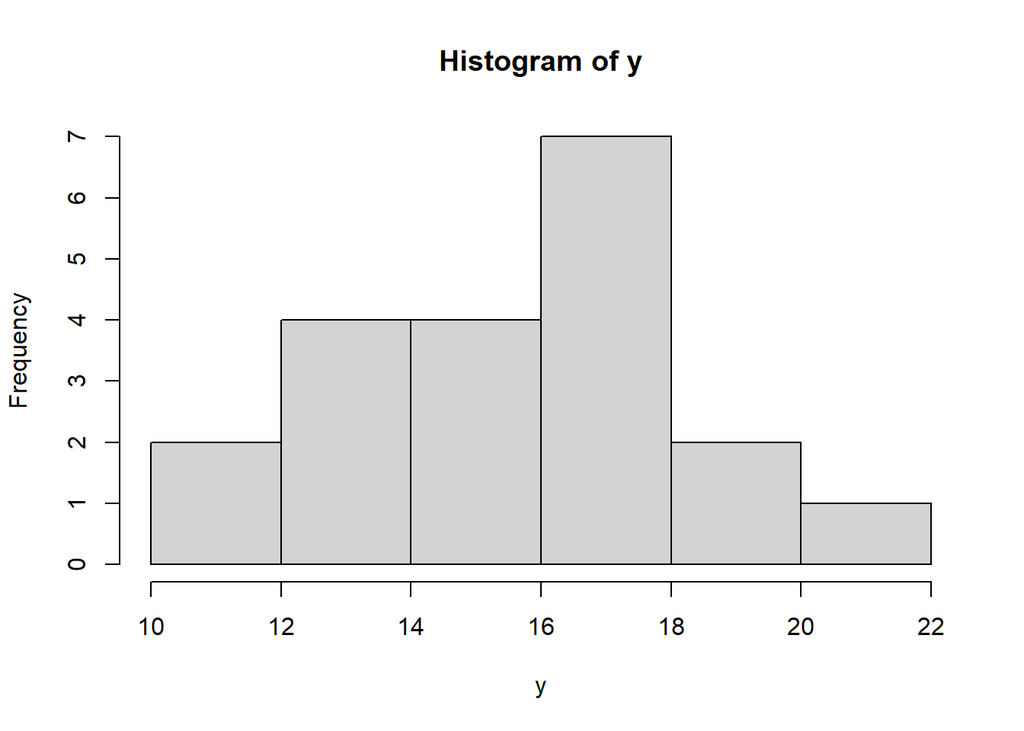

```r
hist(y) #plot of y
```

```r
t.test(y) #95% confidence interval
```

```
##
##  One Sample t-test
##
## data:  y
## t = 28.491, df = 19, p-value < 2.2e-16
## alternative hypothesis: true mean is not equal to 0
## 95 percent confidence interval:
##  14.50547 16.80569
## sample estimates:
## mean of x
##  15.65558
```

```r
t.test(y,conf.level=0.90) #90% confidence interval
```

```
##
##  One Sample t-test
##
## data:  y
## t = 28.491, df = 19, p-value < 2.2e-16
## alternative hypothesis: true mean is not equal to 0
## 90 percent confidence interval:
##  14.70542 16.60573
## sample estimates:
## mean of x
##  15.65558
```

Gaussian distributions are not the only to exist. *Gamma distributions* are skewed and we can identify CIs in the same way.

```r
a <- 2 #distribution will have shape a and scale s
s <- 3

y <- rgamma(30,shape=a,scale=s)
mu.pop <- a*s #mean
sd.pop <- sqrt(a*s^2) #SD
mu.pop
```

```
## [1] 6
```

```r
mean(y)
```

```
## [1] 5.80682
```

```r
sd.pop
```

```
## [1] 4.242641
```

```r
sd(y)
```

```
## [1] 3.291666
```

```r
y
```

```
##  [1]  3.5548345  4.4147705  6.0206208  7.6035704  8.7599662  3.5373271
##  [7]  7.7287543  9.5764566  0.9592948  1.8380700  8.2047337 10.8979502
## [13]  2.4941513 10.3023200  1.5388769  1.3392566  6.7799795  9.1920368
## [19]  3.6905311  7.4072687  2.0009927  0.7492193 11.7285407  5.7555846
## [25]  6.5958424  8.4627877  9.7642247  5.9063200  2.1067942  5.2935353
```

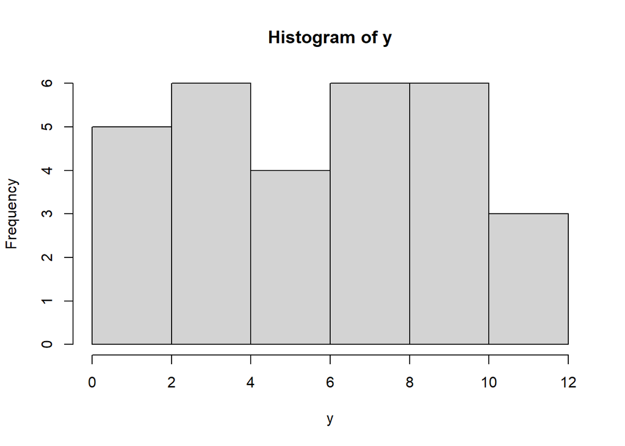

```r
hist(y)
```

```r
t.test(y)
```

```
##
##  One Sample t-test
##
## data:  y
## t = 9.6624, df = 29, p-value = 1.43e-10
## alternative hypothesis: true mean is not equal to 0
## 95 percent confidence interval:
##  4.577692 7.035949
## sample estimates:
## mean of x
##   5.80682
```

We can use the binom package to get exact confidence intervals for a number of events in a number of trials

```r
library(binom)
binom.confint(17,22,methods="exact") #exact 95% binomial CI for 17 events in 22 trials
```

```
##   method  x  n      mean     lower     upper
## 1  exact 17 22 0.7727273 0.5462964 0.9217937
```

```r
binom.confint(1,15,conf.level=0.90,methods="exact") #exact 90% Binomial Confidence Interval for 1 event in 15 trials
```

```
##   method x  n       mean       lower     upper
## 1  exact 1 15 0.06666667 0.003413713 0.2793962
```

We can also calculate CIs for asymptotic data with very very large sample sizes, noting the negative limit.

```r
binom.confint(1,15,conf.level=0.90,methods="asymptotic") #90% CI for 1 event in 15 trials
```

```
##       method x  n       mean       lower     upper
## 1 asymptotic 1 15 0.06666667 -0.03927197 0.1726053
```

```r
#lower limit is below 0 but barely
```

##Descriptive Stats Lecture 1 Significance doesn’t always have to be 0.05, could make it higher for preliminary studies so you don’t rule something out too soon

```r
x <- c(15,37,12,NA,22,11)

mean(x)
```

```
## [1] NA
```

```r
mean(x,na.rm=T)
```

```
## [1] 19.4
```

```r
median(x)
```

```
## [1] NA
```

*Quantiles* are like percentiles but expressed as a decimal instead of a percentage (whole number)

```r
#quantile(x,prob) is the function used here
#x is a vector of numbers and prob is one of the quantiles
var(x)
```

```
## [1] NA
```

```r
#standard deviation, square root of variance
sd(x)
```

```
## [1] NA
```

```r
#as N increases, sample var and SD approach the pop var and SD
#median absolute deviation (MAD) finds the difference between each value and the median, good for outliers
mad(x)
```

```
## [1] NA
```

## Descriptive Stats Lecture 3

*Marginal Sums* can be for rows or columns and is the sum of the total # of observations in either the rows or the columns. (Basically how many N’s you have) *Conditional Probabilities* are different but can also be pulled from the table: P(a|b)–probability that a happens given b. If the variables are *independent*, you only use the marginal values to calculate probabilities.

```r
library(gmodels)
#attach(monica) #this does not exist apparently, not in documentation at all
#CrossTable(sex,outcome,prop.chisq=FALSE) #turns off Chi2 stat
```

Testing independence is the basis for the Chi2 test. We will look at (Observed cell counts-expected cell counts)^2/Expected (to normalize) - this is a hypothesis test where the null hypothesis is that there’s no difference between observed and expected - always non-negative because the difference squared is always positive - if the variables are indepedent then X-squared=0

```r
D <- matrix (c(2550, 975, 2055, 787), nrow = 2, dimnames =  list(c("m","f"),c("live","dead")))
D
```

```
##   live dead
## m 2550 2055
## f  975  787
```

```r
chisq.test(D)
```

```
##
##  Pearson's Chi-squared test with Yates' continuity correction
##
## data:  D
## X-squared = 1.349e-07, df = 1, p-value = 0.9997
```

Yates continuity correction is the default, in this case it’s irrelevant because our sample size is so big. df=(rows-1) x (columns-1)

*Odds* is another descriptive statistic and is equal to p/(1-p) - Probability and odds have a 1:1 correspondence, as well as log(odds) *Odds Ratio* is the odds of two events in a row

```r
H <- matrix(c(2, 7, 8, 3), nrow = 2, dimnames = list(c("No Drug","Drug"), c("live","dead"))) #ten patients per group
H
```

```
##         live dead
## No Drug    2    8
## Drug       7    3
```

To test the null Hypothesis that the Odds Ratio-1, we can use the Chi squared test of independence or *Fisher’s Exact Test*, good for smaller sample sizes

```r
fisher.test(H)
```

```
##
##  Fisher's Exact Test for Count Data
##
## data:  H
## p-value = 0.06978
## alternative hypothesis: true odds ratio is not equal to 1
## 95 percent confidence interval:
##  0.007870555 1.133635839
## sample estimates:
## odds ratio
##  0.1226533
```